# Main title of my document

## Title of a main section

Get to know how to generate an R Markdown file: https://intro2r.com/new-rm.html

Get to know the R markdown anatomy: https://intro2r.com/r-markdown-anatomy.html#formatted-text

### Title of a subsection

R is both a **programming language** and an **interactive environment** for data exploration and statistics and also for computing. The easiest way **to get started** with R is by using the **graphic interface RStudio**. The main way of working with R is the console, where you enter commands and view results. RStudio surrounds this with various conveniences. In addition to the console panel, **RStudio provides** panels containing:

1. **Console panel** for sending R commands;
2. **Text editor panel** where R commands can be recorded for future reference;
3. **Environment panel** with a list of variables, which contain values that R has been told to save from previous commands;
4. **File manager panel**;
5. **Help panel** on the functions available in R;
6. **Plots panel**.

### Title of a subsection

R is always pointed at a **specific directory on your computer**, the working directory. The command for setting a working directory is **setwd()**. Check out the **help panel**.

### A section of code

```r
library(raster)
```

### Title of a subsection

R is always pointed at a **specific directory on your computer**, the working directory. The command for setting a working directory is **setwd()**. Check out the **help panel**.

### A section of code

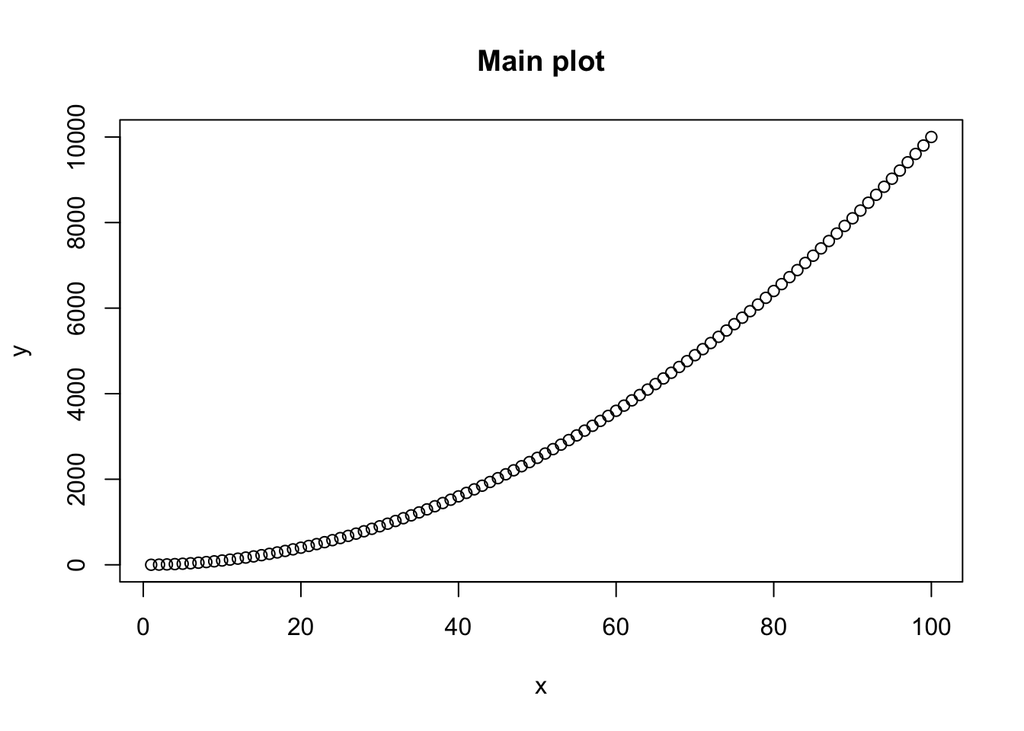

```r
# my comment to the code
data <- data.frame(x=seq(1,100,by=1),y=seq(1,100,by=1)^2)

# my comment to the code
plot(data, main="Main plot")
```

## References

Global change impacts on biodiversity. Available at: https://damariszurell.github.io/HU-GCIB

Monash Bioinformatics Platform. Available at: https://monashdatafluency.github.io/r-intro-2/

Hijmans, R.J. (2020) Spatial Data Science with R. Available at: https://rspatial.org/raster/index.html